# Project: Investigate TMDb movies Dataset

- Introduction
- Data Wrangling
- Exploratory Data Analysis
- Conclusions

## Introduction

TMDb movies dataset is a data set contains information about 10,000 movies collected from The Movie Database (TMDb), it includes movies infromation, budget, revenue, user ratings, avarage votes and popularity. It is a helpful source of information for analysing the movies' net profit, sucessful genres and there relation with other properties, popularity and revenue of movies. The following question will try to help in analysing and extracting useful insights from the data set.

#### Net Profit related questions

1. What is the net profit of each movie?
2. Research Question 2: What is the % of net profit (avg) out of the revenue (avg)?

#### Genres related questions

1. What are the Frequent Genres across all movies in the dataset?
2. What are the Top 3 Genres that achieve the Highest Profit each year?
3. What are the Top 10 Genres with the highest profit across all movies over all the years found in the dataset?
4. What are the populare genres over each year (top 3 genres for each year)?
5. Which genres are most popular from year to year?

#### Popularity related questions

1. What is the correlation between revenue and popularity, budget, vote count, vote average, runtime, release year?
2. what is the correlation between vote counts, average votes and popularity?

#### Revenue related questions

1. How many movies achieve high revenue, where 'high revenue' is revenue higher than the average of all?
2. What are the Top 5 movies in terms of revenue?
3. What kinds of properties are associated with movies that have high revenue?

## Important Note:

The following cell will upgrade pandas to it's latest version and will restast the kernal. Please press Ok button when pop-up appears on screen.

```python
import sys, IPython

#upgrade pandas to latest
!{sys.executable} -m pip install pandas --upgrade

#restart the kernal to use use latest pandas instead of version 0.23
IPython.Application.instance().kernel.do_shutdown(True) #automatically restarts kernel, please click "Ok"
```

[output not shown]

```
{'status': 'ok', 'restart': True}
```

```python
# import libraries
import pandas as pd
import numpy as np
import matplotlib.pyplot as plt
from datetime import datetime
% matplotlib inline

#be sure that pandas version is the latest now (1.1.5 or higher)
pd.__version__
```

```
'1.1.5'
```

```python
# the following functions are supportive functions

from IPython.core.display import display, HTML
from base64 import b64encode
from io import BytesIO


def printdf(dfs, titles=None):
    '''
    Print pandas DataFrames side-by-side.

            Parameters:
                    dfs (list or DataFrame): list of DataFrames or sigle DataFrame
                    titles (list): list of strings acts as caption for each dataframe respectively

    '''
    dfs = [dfs] if (type(dfs)!=list) else dfs
    titles = [titles] if (type(titles)==str) else titles
    titles = ["dataframe_" + str(i+1) for i in range(len(dfs))] if titles==None else titles
    output = ""
    for title, df in dict(zip(titles, dfs)).items():
        output += df.style.set_table_attributes("style='display:inline;margin-right:20px;'").set_caption(title)._repr_html_() + "\xa0\xa0\xa0"
    display(HTML(output))


def showplotdf(first, second, title=None):
    '''
    Print pandas DataFrames and figure/plot side-by-side.

            Parameters:
                    first (DataFrame or figure or plot): to be printed on the left side
                    second (DataFrame or figure or plot): to be printed on the right side

    '''
    def _identify(obj):
        obj = obj._repr_html_() if isinstance(obj, pd.DataFrame) else obj

        if str(type(obj)) =="<class 'matplotlib.axes._subplots.AxesSubplot'>" or type(obj)==plt.Figure:
            obj = obj.get_figure() if type(obj)!=plt.Figure else obj
            figdata = BytesIO()
            #plt.tight_layout()
            obj.savefig(figdata, format='png', bbox_inches = "tight")
            plt.close()
            obj =  f'<img src="data:…)).decode()}"/>'

        return obj

    caption = f'<caption style="color:white;background-color:#999;padding:5px;text-align:center">{title}</caption>' if title != None else ''
    width = f'width:100%'
    second = _identify(second)
    first = _identify(first)

    datatable = (f"""<table style="{width}">
                        {caption}
                        <tr style="background-color: transparent;vertical-align: top;">
                            <td style="background-color: transparent;vertical-align: top;text-align: left;">{first}</td>
                            <td style="background-color: transparent;vertical-align: top;text-align: left;">{second}</td>
                        </tr>
                    </table>""")
    display(HTML("<style>div.output_scroll { height: auto; }</style>"))
    display(HTML(datatable))
```

## Data Wrangling

### Investigating General Properties of the dataset

```python
#load & display data
df = pd.read_csv('tmdb-movies.csv')
df.head()
```

|  | id | imdb_id | popularity | budget | revenue | original_title | cast | homepage | director | tagline | ... | overview | runtime | genres | production_companies | release_date | vote_count | vote_average | release_year | budget_adj | revenue_adj |
| --- | --- | --- | --- | --- | --- | --- | --- | --- | --- | --- | --- | --- | --- | --- | --- | --- | --- | --- | --- | --- | --- |
| 0 | 135397 | tt0369610 | 32.985763 | 150000000 | 1513528810 | Jurassic World | Chris Pratt\|Bryce Dallas Howard\|Irrfan Khan\|Vi... | http://www.jurassicworld.com/ | Colin Trevorrow | The park is open. | ... | Twenty-two years after the events of Jurassic ... | 124 | Action\|Adventure\|Science Fiction\|Thriller | Universal Studios\|Amblin Entertainment\|Legenda... | 6/9/15 | 5562 | 6.5 | 2015 | 1.379999e+08 | 1.392446e+09 |
| 1 | 76341 | tt1392190 | 28.419936 | 150000000 | 378436354 | Mad Max: Fury Road | Tom Hardy\|Charlize Theron\|Hugh Keays-Byrne\|Nic... | http://www.madmaxmovie.com/ | George Miller | What a Lovely Day. | ... | An apocalyptic story set in the furthest reach... | 120 | Action\|Adventure\|Science Fiction\|Thriller | Village Roadshow Pictures\|Kennedy Miller Produ... | 5/13/15 | 6185 | 7.1 | 2015 | 1.379999e+08 | 3.481613e+08 |
| 2 | 262500 | tt2908446 | 13.112507 | 110000000 | 295238201 | Insurgent | Shailene Woodley\|Theo James\|Kate Winslet\|Ansel... | http://www.thedivergentseries.movie/#insurgent | Robert Schwentke | One Choice Can Destroy You | ... | Beatrice Prior must confront her inner demons ... | 119 | Adventure\|Science Fiction\|Thriller | Summit Entertainment\|Mandeville Films\|Red Wago... | 3/18/15 | 2480 | 6.3 | 2015 | 1.012000e+08 | 2.716190e+08 |
| 3 | 140607 | tt2488496 | 11.173104 | 200000000 | 2068178225 | Star Wars: The Force Awakens | Harrison Ford\|Mark Hamill\|Carrie Fisher\|Adam D... | http://www.starwars.com/films/star-wars-episod... | J.J. Abrams | Every generation has a story. | ... | Thirty years after defeating the Galactic Empi... | 136 | Action\|Adventure\|Science Fiction\|Fantasy | Lucasfilm\|Truenorth Productions\|Bad Robot | 12/15/15 | 5292 | 7.5 | 2015 | 1.839999e+08 | 1.902723e+09 |
| 4 | 168259 | tt2820852 | 9.335014 | 190000000 | 1506249360 | Furious 7 | Vin Diesel\|Paul Walker\|Jason Statham\|Michelle ... | http://www.furious7.com/ | James Wan | Vengeance Hits Home | ... | Deckard Shaw seeks revenge against Dominic Tor... | 137 | Action\|Crime\|Thriller | Universal Pictures\|Original Film\|Media Rights ... | 4/1/15 | 2947 | 7.3 | 2015 | 1.747999e+08 | 1.385749e+09 |

5 rows × 21 columns

### Checking Columns names

Make sure that all column names are lowercase and no spaces, underscore instead for ease of use.

```python
df.columns
```

```
Index(['id', 'imdb_id', 'popularity', 'budget', 'revenue', 'original_title',
       'cast', 'homepage', 'director', 'tagline', 'keywords', 'overview',
       'runtime', 'genres', 'production_companies', 'release_date',
       'vote_count', 'vote_average', 'release_year', 'budget_adj',
       'revenue_adj'],
      dtype='object')
```

### Check null values

Null values are reducing the analysis results accuracy.

Either the Non-null count not equal number of entries or isna() returns True indicates that there is a null value

```python
df.info()
```

```
<class 'pandas.core.frame.DataFrame'>
RangeIndex: 10866 entries, 0 to 10865
Data columns (total 21 columns):
 #   Column                Non-Null Count  Dtype
---  ------                --------------  -----
 0   id                    10866 non-null  int64
 1   imdb_id               10856 non-null  object
 2   popularity            10866 non-null  float64
 3   budget                10866 non-null  int64
 4   revenue               10866 non-null  int64
 5   original_title        10866 non-null  object
 6   cast                  10790 non-null  object
 7   homepage              2936 non-null   object
 8   director              10822 non-null  object
 9   tagline               8042 non-null   object
 10  keywords              9373 non-null   object
 11  overview              10862 non-null  object
 12  runtime               10866 non-null  int64
 13  genres                10843 non-null  object
 14  production_companies  9836 non-null   object
 15  release_date          10866 non-null  object
 16  vote_count            10866 non-null  int64
 17  vote_average          10866 non-null  float64
 18  release_year          10866 non-null  int64
 19  budget_adj            10866 non-null  float64
 20  revenue_adj           10866 non-null  float64
dtypes: float64(4), int64(6), object(11)
memory usage: 1.7+ MB
```

```python
df.isna().any()
```

```
id                      False
imdb_id                  True
popularity              False
budget                  False
revenue                 False
original_title          False
cast                     True
homepage                 True
director                 True
tagline                  True
keywords                 True
overview                 True
runtime                 False
genres                   True
production_companies     True
release_date            False
vote_count              False
vote_average            False
release_year            False
budget_adj              False
revenue_adj             False
dtype: bool
```

### Check for duplicated rows

Duplicate data always reduce the analysis results quality. For example, calculating the count, sum, average will consider one movie as N movies, where N is the number of duplicated rows for that movies.

The following table will return the duplicate movies if any

```python
# check if there are duplicated rows (movies)
df[df.duplicated()]
```

|  | id | imdb_id | popularity | budget | revenue | original_title | cast | homepage | director | tagline | ... | overview | runtime | genres | production_companies | release_date | vote_count | vote_average | release_year | budget_adj | revenue_adj |
| --- | --- | --- | --- | --- | --- | --- | --- | --- | --- | --- | --- | --- | --- | --- | --- | --- | --- | --- | --- | --- | --- |
| 2090 | 42194 | tt0411951 | 0.59643 | 30000000 | 967000 | TEKKEN | Jon Foo\|Kelly Overton\|Cary-Hiroyuki Tagawa\|Ian... | NaN | Dwight H. Little | Survival is no game | ... | In the year of 2039, after World Wars destroy ... | 92 | Crime\|Drama\|Action\|Thriller\|Science Fiction | Namco\|Light Song Films | 3/20/10 | 110 | 5.0 | 2010 | 30000000.0 | 967000.0 |

1 rows × 21 columns

##### There is only 1 duplicated movie

### Check values for any illogical value such as very small values in fields that is supposed to have big values

Can be check from **min** values, small illogical values might decrese the analysis results accuracy

```python
df.describe()
```

|  | id | popularity | budget | revenue | runtime | vote_count | vote_average | release_year | budget_adj | revenue_adj |
| --- | --- | --- | --- | --- | --- | --- | --- | --- | --- | --- |
| count | 10866.000000 | 10866.000000 | 1.086600e+04 | 1.086600e+04 | 10866.000000 | 10866.000000 | 10866.000000 | 10866.000000 | 1.086600e+04 | 1.086600e+04 |
| mean | 66064.177434 | 0.646441 | 1.462570e+07 | 3.982332e+07 | 102.070863 | 217.389748 | 5.974922 | 2001.322658 | 1.755104e+07 | 5.136436e+07 |
| std | 92130.136561 | 1.000185 | 3.091321e+07 | 1.170035e+08 | 31.381405 | 575.619058 | 0.935142 | 12.812941 | 3.430616e+07 | 1.446325e+08 |
| min | 5.000000 | 0.000065 | 0.000000e+00 | 0.000000e+00 | 0.000000 | 10.000000 | 1.500000 | 1960.000000 | 0.000000e+00 | 0.000000e+00 |
| 25% | 10596.250000 | 0.207583 | 0.000000e+00 | 0.000000e+00 | 90.000000 | 17.000000 | 5.400000 | 1995.000000 | 0.000000e+00 | 0.000000e+00 |
| 50% | 20669.000000 | 0.383856 | 0.000000e+00 | 0.000000e+00 | 99.000000 | 38.000000 | 6.000000 | 2006.000000 | 0.000000e+00 | 0.000000e+00 |
| 75% | 75610.000000 | 0.713817 | 1.500000e+07 | 2.400000e+07 | 111.000000 | 145.750000 | 6.600000 | 2011.000000 | 2.085325e+07 | 3.369710e+07 |
| max | 417859.000000 | 32.985763 | 4.250000e+08 | 2.781506e+09 | 900.000000 | 9767.000000 | 9.200000 | 2015.000000 | 4.250000e+08 | 2.827124e+09 |

## Observations

It's clear from the above checks over the dataframe that there are...

**Some missing data in the following columns**

- imdb_id (Not useful in the analysis)
- homepage (Not useful in the analysis)
- director (Not useful in the analysis)
- tagline (Not useful in the analysis)
- keywords (Not useful in the analysis)
- overview (Not useful in the analysis)
- genres (Useful in the analysis)
- production_companies (Useful in the analysis)

**Some field's datatypes are not in the appropriate format in the following colums**

- release_date (Not useful in the analysis) > to be datetime
- genres (Useful in the analysis) > to be string
- cast (Useful in the analysis) > to be string
- production_companies (Useful in the analysis) > to be string

**Some rows are Duplicated**

- Number of duplicated rows are 1 (movie TAKKEN)

**Some Values important for the analysis are Zeros or Very small**

- budget and revenue are 0 of very small for some movies

## Data Cleaning

1. Delete all non-useful columns
2. Fix datatypes to facilitate the analysis
3. Delete Duplicate rows (movies)
4. Delete movies with budget and revenue equals to Zero or Very small values

#### 1. Delete all non-useful columns

Those columns will not help in the analysis

```python
df.drop(['id', 'imdb_id', 'homepage', 'tagline', 'keywords'], axis = 1, inplace=True, errors='ignore')
#check
df.head(1)
```

|  | popularity | budget | revenue | original_title | cast | director | overview | runtime | genres | production_companies | release_date | vote_count | vote_average | release_year | budget_adj | revenue_adj |
| --- | --- | --- | --- | --- | --- | --- | --- | --- | --- | --- | --- | --- | --- | --- | --- | --- |
| 0 | 32.985763 | 150000000 | 1513528810 | Jurassic World | Chris Pratt\|Bryce Dallas Howard\|Irrfan Khan\|Vi... | Colin Trevorrow | Twenty-two years after the events of Jurassic ... | 124 | Action\|Adventure\|Science Fiction\|Thriller | Universal Studios\|Amblin Entertainment\|Legenda... | 6/9/15 | 5562 | 6.5 | 2015 | 1.379999e+08 | 1.392446e+09 |

##### Columns 'id', 'imdb_id', 'homepage', 'tagline', 'keywords' have been removed from the dataset as they are not useful in the anatysis process.

#### 2. Fix datatypes to facilitate the analysis

```python
df.release_date = pd.to_datetime(df.release_date)
df.genres = df.genres.astype("string")
df.cast = df.cast.astype("string")
df.production_companies = df.production_companies.astype("string")

#check types after type cast
print(f'release_date:{df.release_date.dtype.type} , genres:{df.genres.dtype.type} , cast: {df.cast.dtype.type} , production_companies:{df.production_companies.dtype.type}')
```

```
release_date:<class 'numpy.datetime64'> , genres:<class 'str'> , cast: <class 'str'> , production_companies:<class 'str'>
```

##### Data types have been corrected

#### 3. Delete Duplicate rows (movies)

```python
df.drop(df[df.duplicated()].index, axis=0, inplace=True)

#display duplicated again to be sure that there is no duplicated rows
df[df.duplicated()]
```

|  | popularity | budget | revenue | original_title | cast | director | overview | runtime | genres | production_companies | release_date | vote_count | vote_average | release_year | budget_adj | revenue_adj |
| --- | --- | --- | --- | --- | --- | --- | --- | --- | --- | --- | --- | --- | --- | --- | --- | --- |

##### Duplicated movies have been removed

#### 4. Delete movies with budget or revenue equals to Zero or very small amount

> Assumption: Let's consider the minimum acceptable budget and revenue = 1000

```python
min_acceptable_bud_revenue = 1000
df.drop(df[(df.budget<min_acceptable_bud_revenue)|(df.revenue<min_acceptable_bud_revenue)].index, axis=0, inplace=True)

# Checks
df_check = df[(df.budget < min_acceptable_bud_revenue )|(df.revenue < min_acceptable_bud_revenue)]
printdf(df_check, f'Ensure that there are no budget or revenue less than {min_acceptable_bud_revenue}')
printdf(df.describe(), 'DataFrame Description to check the min values agian')
```

Ensure that there are no budget or revenue less than 1000

|  | popularity | budget | revenue | original_title | cast | director | overview | runtime | genres | production_companies | release_date | vote_count | vote_average | release_year | budget_adj | revenue_adj |
| --- | --- | --- | --- | --- | --- | --- | --- | --- | --- | --- | --- | --- | --- | --- | --- | --- |

DataFrame Description to check the min values agian

|  | popularity | budget | revenue | runtime | vote_count | vote_average | release_year | budget_adj | revenue_adj |
| --- | --- | --- | --- | --- | --- | --- | --- | --- | --- |
| count | 3819.000000 | 3819.000000 | 3819.000000 | 3819.000000 | 3819.000000 | 3819.000000 | 3819.000000 | 3819.000000 | 3819.000000 |
| mean | 1.198029 | 37462018.172820 | 108640982.322074 | 109.312385 | 531.583399 | 6.170359 | 2001.278607 | 44543600.240719 | 138256695.197166 |
| std | 1.480022 | 42262678.368143 | 177054104.928261 | 19.842850 | 882.918464 | 0.793914 | 11.297486 | 44834508.279723 | 216708152.773625 |
| min | 0.001117 | 6000.000000 | 1938.000000 | 26.000000 | 10.000000 | 2.200000 | 1960.000000 | 6310.011496 | 1840.604417 |
| 25% | 0.465100 | 10000000.000000 | 14163246.000000 | 96.000000 | 72.000000 | 5.700000 | 1995.500000 | 13352839.054741 | 19144790.996118 |
| 50% | 0.804481 | 24000000.000000 | 45892212.000000 | 106.000000 | 206.000000 | 6.200000 | 2004.000000 | 30306534.840514 | 62466935.985678 |
| 75% | 1.380228 | 50000000.000000 | 125561662.500000 | 119.000000 | 583.000000 | 6.700000 | 2010.000000 | 60767198.028550 | 164847797.604461 |
| max | 32.985763 | 425000000.000000 | 2781505847.000000 | 338.000000 | 9767.000000 | 8.400000 | 2015.000000 | 425000000.000000 | 2827123750.411890 |

##### Movies associated with Small budget and revenue values (under the defined threshold) have been removed

## Exploratory Data Analysis

### Net Profit related questions

### 1. What is the net profit of each movie?

```python
#subtract the budget from the revenue
df['profit'] = df.revenue - df.budget

#display average profit
print(f'Average movies profit is: {int(df.profit.mean())}')

#display the top 5 movies with highest profit
df_profit = df[['original_title', 'profit']].sort_values('profit', ascending=False)

# 5 movies with profit around the mean profit of all movies
df_mean_profit =  df_profit.iloc[(df_profit.profit - df_profit.profit.mean()).abs().argsort()[:5]]

#display
printdf([df_profit.head(5), df_mean_profit],
        ['Top 5 movies in terms of profit', '5 movies with profit around the mean profit of all movies'])
```

```
Average movies profit is: 71178964
```

Top 5 movies in terms of profit

|  | original_title | profit |
| --- | --- | --- |
| 1386 | Avatar | 2544505847 |
| 3 | Star Wars: The Force Awakens | 1868178225 |
| 5231 | Titanic | 1645034188 |
| 0 | Jurassic World | 1363528810 |
| 4 | Furious 7 | 1316249360 |

5 movies with profit around the mean profit of all movies

|  | original_title | profit |
| --- | --- | --- |
| 8718 | The Cell | 71155843 |
| 9952 | Vanishing Point | 70966306 |
| 5449 | 2 Guns | 70940411 |
| 4469 | The Possession | 71446075 |
| 6578 | Blood Diamond | 70877916 |

##### Net profit of the movies, which is the difference between the renvenue and budget, will help understand how much each movie earned after deducting all the allocated budget as well as relate it to movies properties

### 2. What is the % of net profit (avg) out of the revenue (avg)?

```python
precent_profit_revenue = df.profit.mean() * 100/ df.revenue.mean()

print(f'The percentage of avg net profit out of the avg revenue is: {round(precent_profit_revenue,1)}%')
```

```
The percentage of avg net profit out of the avg revenue is: 65.5%
```

# Genres related questions

Genres are one of the most important properties that affects the popularity, votes and revenue

### 3. What are the Frequent Genres across all movies in the dataset?

Count of all movies in each genre across all movies in the dataset

|  | genres |
| --- | --- |
| Drama | 1744 |
| Comedy | 1340 |
| Thriller | 1194 |
| Action | 1076 |
| Adventure | 743 |
| Romance | 657 |
| Crime | 649 |
| Science Fiction | 516 |
| Horror | 458 |
| Family | 420 |
| Fantasy | 391 |
| Mystery | 343 |
| Animation | 199 |
| Music | 133 |
| History | 128 |
| War | 119 |
| Western | 52 |
| Documentary | 35 |
| Foreign | 13 |
| TV Movie | 1 |

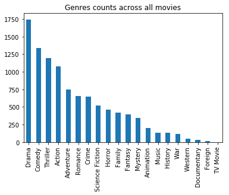

```python
# convert | tokenized string with list
df.genres = df.genres.str.split('|') if df.genres.dtype.type==str else df.genres
# explode tokens to rows
df_genres = df.explode('genres')
# get value counts
genres_counts = df_genres['genres'].value_counts()
# display
showplotdf(pd.DataFrame(genres_counts), genres_counts.plot.bar(title='Genres counts across all movies'),
          'Count of all movies in each genre across all movies in the dataset')
```

### 4. What are the Top 3 Genres that achieve the Highest Profit in each year?

```python
# sort genres dataframe
df_genres_sort = df_genres.sort_values(['release_year','original_title', 'popularity'], ascending=False)

# group by release_year and genres then the get profit sum
dgp = (df_genres_sort.groupby(['release_year','genres'], sort=False).agg({'profit':'sum'}))

# sort by profit and get largest 3 values
grouped = dgp['profit'].groupby('release_year', group_keys=False)
result = grouped.apply(lambda x: x.sort_values(ascending=False).nlargest(n=3))
result = pd.DataFrame(result)

printdf([result.head(15), result.tail(15)],
        ['Top 3 genres in last 5 years in dataset', 'Top 3 genres in first 5 years in dataset'])
```

Top 3 genres in last 5 years in dataset

| release_year | genres | profit |
| --- | --- | --- |
| 2015 | Action | 9796359014 |
|  | Adventure | 9761223512 |
|  | Science Fiction | 7240628560 |
| 2014 | Action | 9212713803 |
|  | Adventure | 8088163249 |
|  | Science Fiction | 5350210738 |
| 2013 | Adventure | 6834437208 |
|  | Action | 5949391594 |
|  | Science Fiction | 4869901793 |
| 2012 | Adventure | 8240816933 |
|  | Action | 7290355380 |
|  | Drama | 5384953490 |
| 2011 | Adventure | 7086315939 |
|  | Action | 6287719937 |
|  | Family | 4694930697 |

Top 3 genres in first 5 years in dataset

| release_year | genres | profit |
| --- | --- | --- |
| 1964 | Music | 151773276 |
|  | Family | 151272727 |
|  | Thriller | 126264839 |
| 1963 | Thriller | 86873353 |
|  | Adventure | 77398765 |
|  | Action | 69398765 |
| 1962 | Adventure | 148500000 |
|  | Drama | 103579846 |
|  | Action | 93500000 |
| 1961 | Adventure | 234780014 |
|  | Comedy | 221980014 |
|  | Family | 212880014 |
| 1960 | Drama | 101193052 |
|  | Action | 50905000 |
|  | History | 48000000 |

##### Using the porfit calculated before, it is possible to get the profit of each genre for each year. For exmple, in 2015 it's clear that Action genre achieved the highest profit of 9,796,359,014 while in 1960 Drama achieved the highest profit of 101,193,052

### 5. What are the Top 10 Genres with the highest profit across all movies over all the years found in the dataset?

Top 10 Genres with the highest profit

|  | profit |
| --- | --- |
| Adventure | 111126445901 |
| Action | 108558430318 |
| Comedy | 87374955013 |
| Drama | 81174390412 |
| Thriller | 72791518324 |
| Family | 59881511872 |
| Fantasy | 58601625745 |
| Science Fiction | 56049335570 |
| Romance | 38944067827 |
| Animation | 36317190286 |

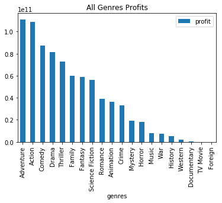

```python
top10_genres = df_genres.groupby(['genres']).agg({'profit': 'sum'}).sort_values('profit', ascending=False)
top = top10_genres['profit'].head(10).to_dict()

showplotdf(pd.DataFrame.from_dict(top, orient='index', columns=['profit']),
           top10_genres.plot.bar(title='All Genres Profits'),
          'Top 10 Genres with the highest profit')
```

##### The above chart is depicting profit of each genres for all movies in the dataset. It helps visualizing the differences in profit. For example, Comedy genre, which is the 3rd highest in profit, is approximately 7% more than Drama, which is the 4th highest genre. It is worth to say that Drame, which was the 1st highest in number of movies is achieving less profit than Comdey which was the 2nd highest in number of movies

#### 6. What are the populare genres over each year (top 3 genres for each year)?

```python
df_genres_sort = df_genres.sort_values(['release_year','original_title', 'popularity'], ascending=False)

df_genres_pop = (df_genres_sort.groupby(['release_year','genres'], sort=False)
                    .agg({'popularity':'mean', 'vote_average':'mean'}))

grouped = df_genres_pop[['popularity','vote_average']].groupby('release_year', group_keys=False)
result = grouped.apply(lambda x: x.sort_values(by='popularity',ascending=False).nlargest(n=3, columns=['popularity']))

printdf([result.head(15), result.tail(15)],
        ['top 3 genres in last 5 years in dataset', 'top 3 genres in first 5 years in dataset'])
```

top 3 genres in last 5 years in dataset

| release_year | genres | popularity | vote_average |
| --- | --- | --- | --- |
| 2015 | Science Fiction | 7.594638 | 6.422727 |
|  | Western | 7.504550 | 7.300000 |
|  | Adventure | 5.864179 | 6.352941 |
| 2014 | Science Fiction | 5.482694 | 6.426087 |
|  | Adventure | 5.115215 | 6.441379 |
|  | Action | 4.005362 | 6.365909 |
| 2013 | Science Fiction | 2.882717 | 6.470000 |
|  | Adventure | 2.239812 | 6.342424 |
|  | Fantasy | 2.014756 | 6.093750 |
| 2012 | Western | 5.944518 | 7.700000 |
|  | Fantasy | 2.522171 | 6.200000 |
|  | Adventure | 2.517433 | 6.204000 |
| 2011 | Fantasy | 1.977175 | 5.926316 |
|  | Science Fiction | 1.884418 | 6.052174 |
|  | Adventure | 1.861790 | 6.112500 |

top 3 genres in first 5 years in dataset

| release_year | genres | popularity | vote_average |
| --- | --- | --- | --- |
| 1964 | Adventure | 3.153791 | 7.000000 |
|  | Action | 3.153791 | 7.000000 |
|  | War | 2.210475 | 7.700000 |
| 1963 | Adventure | 1.586280 | 7.100000 |
|  | Thriller | 1.364218 | 7.233333 |
|  | Action | 1.357698 | 6.150000 |
| 1962 | Thriller | 3.170651 | 6.700000 |
|  | Action | 1.848380 | 6.400000 |
|  | Adventure | 1.621842 | 6.766667 |
| 1961 | Animation | 2.631987 | 6.600000 |
|  | Romance | 1.752027 | 7.400000 |
|  | Adventure | 1.693268 | 6.800000 |
| 1960 | Horror | 2.610362 | 8.000000 |
|  | Thriller | 2.610362 | 8.000000 |
|  | Adventure | 1.872132 | 7.000000 |

##### Speaking of popularity, the above tables are showing the most popular genres in each year. For example, in 2015 Science Fiction was the most popular genre. However, in 1960 Horror was the most popular genre.

### 7. Which genres are most popular from year to year?

> By summing up the popularity of each genre for all the years found in the dataset, and visualize it on graph, it will be clear which genre is gaining more popularity from year to year

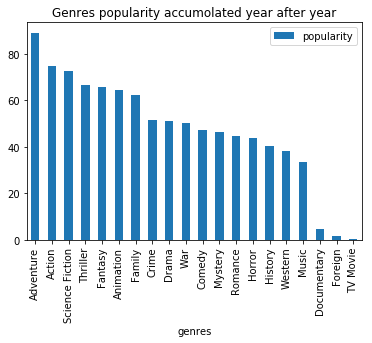

```python
df_genres_pop.reset_index(inplace=True) if (df_genres_pop.index.names!=[None]) else None
grouped = (df_genres_pop[df_genres_pop.genres!='nan'].groupby(['genres','release_year'])
            .sum().sort_index(ascending=False))
grouped = grouped.reset_index() if (grouped.index.names!=[None]) else grouped
grouped = grouped[['genres','popularity']].groupby(['genres']).sum().sort_values(by='popularity',ascending=False)
grouped.plot.bar(title='Genres popularity accumolated year after year');
```

##### the above chart is depicting the generes that are gaining accumolative popularity from year to year as following (in order): Adventure, Action, Science Fiction...etc.

##### The below charts are also explain the increase/decrease of popularity over years found in the dataset

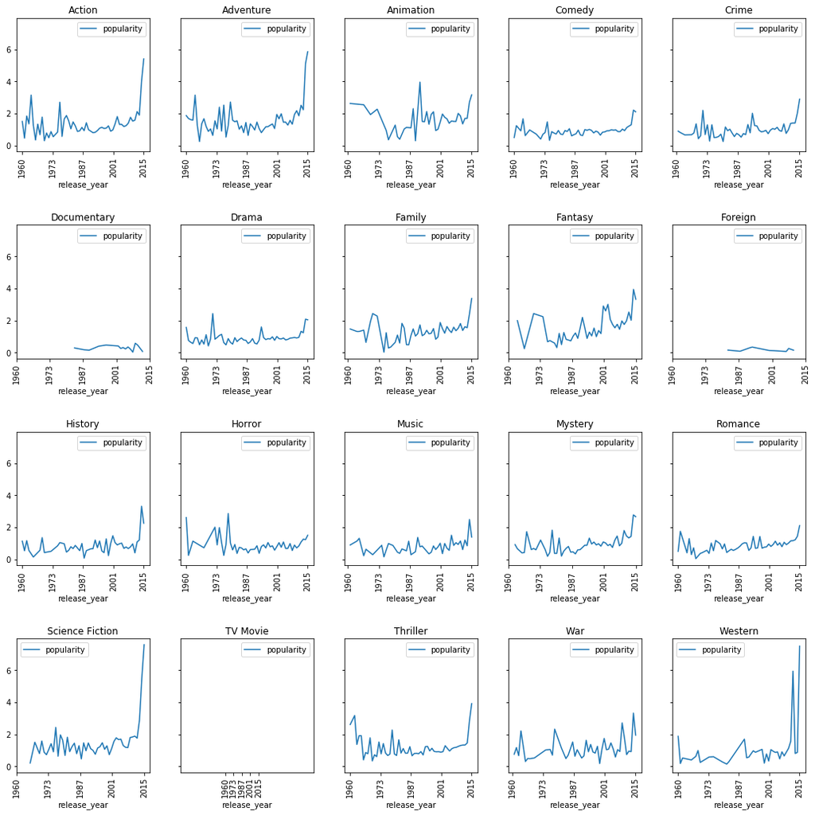

```python
df_genres_pop.reset_index(inplace=True) if (dgp.index.names!=[None]) else None

# discard movies with no genre
grouped = df_genres_pop[df_genres_pop.genres!='nan'].groupby('genres')

# define plots layout
ncols = 5
nrows = int(np.ceil(grouped.ngroups/ncols))
xticks = np.linspace(1960, 2015, num=5)

fig, axes = plt.subplots(nrows=nrows, ncols=ncols, figsize=(15,15), sharey=True)

for (key, ax) in zip(grouped.groups.keys(), axes.flatten()):
    ax.set_xticklabels(xticks.astype(int))
    grouped.get_group(key).plot(ax=ax, x_compat=True, title=key, x='release_year', y='popularity', xticks=xticks, rot=90)

fig.tight_layout(pad=3.0)
ax.legend()
plt.show()
```

##### The above charts are depicting the inclination or declination of genres across all years found in the dataset. The clear observation is that Action, Advanture, Science Fiction and Western genres are gaining too much popularity in recent years. However, Documentary and Foreign are not gainging popularity recently.

# Popularity related questions

### 8. What is the correlation between revenue and popularity, budget, vote count, vote average, runtime, release year?

```python
pd.DataFrame(df.corrwith(df.revenue), columns=['Correlation with Revenue'])
```

|  | Correlation with Revenue |
| --- | --- |
| popularity | 0.614709 |
| budget | 0.688366 |
| revenue | 1.000000 |
| runtime | 0.249990 |
| vote_count | 0.754106 |
| vote_average | 0.227215 |
| release_year | 0.139108 |
| budget_adj | 0.657318 |
| revenue_adj | 0.900561 |
| profit | 0.979204 |

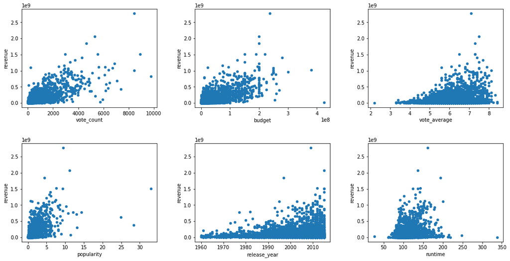

```python
# create scatter plot for movies properties with revenue to visualize the correlation
fig, axes = plt.subplots(nrows=2, ncols=3, figsize=(15,8))
df.plot.scatter(ax=axes[0][0], x='vote_count', y ='revenue');
df.plot.scatter(ax=axes[0][1], x='budget', y ='revenue');
df.plot.scatter(ax=axes[0][2], x='vote_average', y ='revenue');
df.plot.scatter(ax=axes[1][0], x='popularity', y ='revenue');
df.plot.scatter(ax=axes[1][1], x='release_year', y ='revenue');
df.plot.scatter(ax=axes[1][2], x='runtime', y ='revenue');

fig.tight_layout(pad=3.0)
```

##### The above charts is proving that there is a strong positive correlation between revenue and popularity, budget, vote_count and other properties are less in positive correlation strength

### 9. what is the correlation between vote counts, average votes and popularity?

```python
df[['popularity','vote_count', 'vote_average']].corr()
```

|  | popularity | vote_count | vote_average |
| --- | --- | --- | --- |
| popularity | 1.000000 | 0.779619 | 0.318622 |
| vote_count | 0.779619 | 1.000000 | 0.388050 |
| vote_average | 0.318622 | 0.388050 | 1.000000 |

##### The above table is proving that there is a strong positive correlation between popularity and vote_count.

# Revenue related questions

### 10. How many movies achieve high revenue, where 'high revenue' is revenue higher than the average of all?

```python
# get the average (mean) revenue across all movies
avg_revenue =  int(df['revenue'].describe().to_dict()['mean'])
# define high revenue movies as the movies with revenue greater than the average
df_high_rev = df[df.revenue > avg_revenue]
df_high_rev = df_high_rev.sort_values(by='revenue', ascending = False)

print(f'There are {df_high_rev.shape[0]} movies achieve revenue more then the average revenue ({avg_revenue})' )
```

```
There are 1096 movies achieve revenue more then the average revenue (108640982)
```

### 11. What are the Top 5 movies in terms of revenue?

```python
top5_movies = df_high_rev.original_title.head(5)
print(f'Top 5 Movies are: {", ".join(top5_movies)}')
df_high_rev[['original_title','revenue']].reset_index(drop=True).head(5)
```

```
Top 5 Movies are: Avatar, Star Wars: The Force Awakens, Titanic, The Avengers, Jurassic World
```

|  | original_title | revenue |
| --- | --- | --- |
| 0 | Avatar | 2781505847 |
| 1 | Star Wars: The Force Awakens | 2068178225 |
| 2 | Titanic | 1845034188 |
| 3 | The Avengers | 1519557910 |
| 4 | Jurassic World | 1513528810 |

### 12. What kinds of properties are associated with movies that have high revenue?

```python
# getting average and/or top of the properties
avg_profit = int(df_high_rev.profit.mean())
top5_directors = list(df_high_rev.director.value_counts().to_dict().keys())[:5]
top5_years = list(df_high_rev.release_year.value_counts().to_dict().keys())[:5]
top5_movies = df_high_rev.original_title.head(5)
avg_runtime = int(df_high_rev.runtime.mean())
avg_popularity = int(df_high_rev.popularity.max())
avg_budget = int(df_high_rev.budget.mean())
avg_vote_count = int(df_high_rev.vote_count.mean())
avg_vote_average = round(df_high_rev.vote_average.mean(), 1)

df_high_rev_genres = df_genres[df_genres.revenue > avg_revenue]
top5_genres = list(df_high_rev_genres.genres.value_counts().nlargest(5).to_dict().keys())

df_high_rev.cast = df_high_rev.cast.str.split('|') if df_high_rev.cast.dtype.type==str else df_high_rev.cast
df_hrc = df_high_rev.explode('cast')
to5_actors = list(df_hrc.cast.value_counts().nlargest(5).to_dict().keys())

df_high_rev.production_companies = df_high_rev.production_companies.str.split('|') if df_high_rev.production_companies.dtype.type==str else df_high_rev.production_companies
df_hrpc = df_high_rev.explode('production_companies')
top5_pc = list(df_hrpc.production_companies.value_counts().nlargest(5).to_dict().keys())

# display results

print('Properties associated with highest revenue movies (movies with revenue above average):')
print('---------------------------------')
print(f'Average profit: {avg_profit}')
print(f'Top 5 directors: {", ".join(top5_directors)}')
print(f'Average runtime: {avg_runtime}')
print(f'Average popularity: {avg_popularity}')
print(f'Average budget: {avg_budget}')
print(f'Average vote count: {avg_vote_count}')
print(f'Vote average: {avg_vote_average}')
print(f'Top 5 years: {", ".join(map(str, top5_years))}')
print(f'Top 5 actors: {", ".join(to5_actors)}')
print(f'Top 5 production companies: {", ".join(top5_pc)}')
```

[output not shown]

## Conclusions

### Analysis results

According to the above analysis, we have come across different facts about movies profit, genres and revenue. the following are some of the insights.

- Average profit of the movies is: 71,178,964
- Movies achieved highest profit (Top 5): Avatar, Star Wars: The Force Awakens, Titanic, Jurassic World and Furious 7
- Average profit for movies (5 movies sample): The Cell, Vanishing Point, 2 Guns, The Possession and Blood Diamond
- The percentage of average net profit out of the average revenue (considering all movies) is: 65.5%
- Frequent Genres across all movies (Top 5): Drama, Comedy, Thriller, Action, and Adventure
- Genres that achieve the Highest Profit in each year (Top 3 for 2015 as an example): Action, Adventure, Science Fiction
- Genres with the highest profit across all movies over all the years (Top 3): Adventure = 111,126,445,901, Action = 108,558,430,318 , Comedy = 87,374,955,013
- Genres that are gaining popularity year after year are: Adventure, Action and Science Fiction

Looking at the relation between the movies properties, it is clear that:

- There is a **positive correlation** between revenue and popularity, budget, vote_count
- There is also a **positive correlation** between popularity and vote_count

From the revenue perspective, there are 1096 movies achieve revenue more then the average revenue (108,640,982). Digging in to the value, the Top 5 Movies with the highest revenue are:

- **Avatar** 2,781,505,847
- **Star Wars (The Force Awakens)** 2,068,178,225
- **Titanic** 1,845,034,188
- **The Avengers** 1,519,557,910
- **Jurassic World** 1,513,52,8810

### Assumptions & Limitations

- To get movies with high revenue, high revenue threshold is set to the revenue above the average revenue of all movies.
- There are some movies small budget and/or revenue, to make the analysis realistic threshold of 1000 has been used to discard movies with budget and/or revenue less than that threshold.

```python
from subprocess import call
call(['python', '-m', 'nbconvert', 'Investigate_a_Dataset.ipynb'])
```

```
0
```